# Wealth Inequality Trends

## Introduction to the Wealth Inequality Trends Section

The Wealth Inequality Trends section presents a large comprehensive compilation of cross-national time-series data on wealth inequality. This section contains wealth inequality indicators (such as top shares and Gini coefficients) for many countries, as estimated in the existing literature and as derived from existing micro data sources. These data are accompanied by Methodological Tables that provide systematic assessments of the underlying concepts, methods, and sources for the estimation of wealth inequality trends.

This section provides access to, and detailed information about, wealth inequality across countries and over time. To date, there is no comprehensive database that offers `off the shelf` indicators on wealth inequality levels and trends for a variety of different sources. Estimates of wealth distributions are much less settled than those of income distributions, and there is substantial controversy about how wealth inequality has evolved in recent years. A core value-added of this section is that users have access to detailed information about the values provided and methodological information that will help them to navigate the inevitable complexity. Users can also exploit our classification of data types, source types, and units of analysis to guide the choice of the most suitable indicator for their purpose.

## The Structure of the Wealth Inequality Trends Section

In the Wealth Inequality Trends database, each estimate of wealth inequality (`value`) is uniquely identified by the combination of the reference country indexed by a two-digit identifier (`GEO`) and the country name (`GEO_long`), the reference year (`year`), the data source (`source`), the `varcode`, and a `percentile`.

## The `varcode` in the Wealth Inequality Trends Section

**`varcode`** In the Wealth Inequality Trends section, three of the five elements of `varcode` are fixed across the entire database. The constant elements are the first, indexing the dashboard, the second, indexing the sector, and the fourth, describing the wealth concept. Only the `Variable Type` and the `Section-Specific` parts of the `varcode` vary within a source and across sources.

$$\begin{equation}
\notag \underbrace{\textcolor{blue}{t}}_{\text{Section}} -
\underbrace{\textcolor{blue}{hs}}_{\text{Sector}} -
\underbrace{CCC}_{\text{Variable Type}}
- \underbrace{\textcolor{blue}{ netwea }}_{\text{Concept}} -
\underbrace{ZZ}_{\text{Section-Specific}}
\end{equation}$$

### `Section`: Wealth Inequality Trends

*`Section`* The first element of the varcode identifies the *section*, which always equals *t*, i.e. our code for the Wealth Inequality Trends database.

### `Sector`: Household Sector

*`Sector`* The second element of the varcode identifies the *sector*, which is set to *hs*, i.e., our code for the household sector.

### `Concept`: Net Wealth

*`Concept`* The fourth element of the `varcode`, `Concept`, is always set to *netwea*, i.e., our code for net wealth. The precise definition of net wealth, however, not identical across the sources covered by the Wealth Inequality Trends database. Hence, in the *`Methodological Table`* we provide for each source a detailed definition of net wealth, including an explanation of how different asset classes have been treated and valued.

## Construction of the Wealth Inequality Trends Section

The procedure used to construct the Wealth Inequality Trends database is sketched below.

First, we obtain the raw data for each source, which can come in different formats. Second, we transform and harmonize the raw data to fit our standards (in terms of format and structure). In many cases we increase the list of available inequality indicators. In some, we compute the full set of estimates based on existing micro data, such as cross-national survey data. Third, we run a set of tests and append the estimates to the database. In parallel to this process, we develop and write a detailed **Methodological Table**.

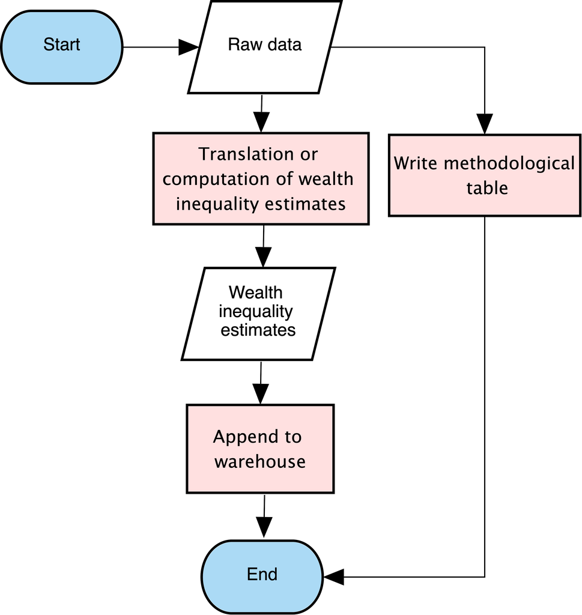

Wealth Inequality Trends Workflow

### Step 1: Obtain and Classify Raw Data

As the data type classification is source-specific, the exercise of assigning a type to each source turns out to be less precise for cross-national sources, as we do not differentiate across countries specificities within the same source. For instance, in the case of the Luxembourg Wealth Study Database [@LIS_LuxembourgWealthStudyDatabase] and the OECD Wealth Distribution Database [@OECD2021_WealthDistributionDatabase], we classify the data type as *Wealth survey*. However, data for one country, Norway, does not come from a wealth survey but from various administrative sources. Similarly, we classify the World Inequality Database [@WorldInequalityDatabase_Data] as a *Mix of sources and methods* to reflect the variety of data sources and estimation methods underlying this source (these details feature in the **Methodological Table** but are not captured in the source-specific classification of data estimation types).

### Step 2: Transformation and Harmonization of Raw Data

All indicators on wealth inequality that we acquire, derive, or estimate from an original data source are classified such that a `percentile` and a `varcode` are associated with each value. Also, the format is standardized so that all inequality indicators are reported on the 0 – 100 scale.

In most cases, we directly acquire estimates of wealth inequality from raw data sources and publications. When possible, we also complement the available set of indicators. To give an example, many sources provide an estimate of the wealth share held by the richest 1% (p99p100) as well as an estimate of the wealth share held by the richest 10% (p90p100). We then use the two indicators to add an estimate of the share of wealth held by the Next 9% (90th–99th Percentiles). When using original micro-data sources, such as cross-national wealth surveys, we provide our own estimates of a range of wealth inequality indicators.

It is also worth noting we take or estimate only one value for each wealth inequality indicator (as indexed by the combination of `percentile` and `varcode`) from each source. This is typically the benchmark estimate as defined in the underlying research paper or database. In future releases of the GC Wealth Project, we aim to explore the within-source variation of wealth inequality estimates by incorporating the full range of estimates reflecting the use of different methodological assumptions.

### Step 3: Testing and Appending

After making sure the acquired, derived, and estimated wealth inequality indicators follow our formatting standards, we run a set of consistency checks and tests before we append them to the Wealth Inequality Trends database.

## Additional Information on the Wealth Inequality Trends Section

For additional information about the Wealth Inequality Trends section, we refer the reader the to the Appendix of this Documentation, where we provide a list of all sources included in the Wealth Inequality Trends database, country-specific information on the coverage of the Wealth Inequality Trends database, and additional information on the precise treatment of selected sources.